# Grid Game discussion and results

The code for grid game creates a GridGame object which is initialised with a grid size (set by tuple of integers), a mode and a random seed.

The parent class is called GridGame and holds most of the attibutes and methods needed to play and solve the games. There are two subclasses: Classic and Relative. There are two methods within these subclasses. One is `.move_time()` which calculates the time need to move to an adjacent cell. The other is an abstractmethod call `.time_on_first_cell()` which returns the value on the first cell for the classic game, and 0 for the relative game. To calculate the correct length of path, the parent methods need to call this.

All other methods are shared: the only difference between the two modes is that the "time cost" of moving from one square to another is different depending on the node.

The next step is to initialise the grid values using the `.set_grid_values()` method. The user can choose a distribution ("integers", "geometric", binomial" or "normal" ) and set paramers for the distribution with key words corresponding to the methods of `numpy.random.default_rng` methods.

The grid can be visualised using `.visualise_grid()` method, which takes an optional `path` argument. path should be a list of grid coordinates.

```python
from grid_game import *
from to_html import *
from matplotlib import pyplot as plt
import pandas as pd
```

```python
save_html('grid_game','task1_report','.')
```

```python
# set random seed here for brevity
random_seed=2
```

## How does the naive algorithm work?

The idea is that a fastest time and fastest path to the finish, from each cell, is stored in an array of same shape as the grid.

For the first iteration, we restrict all moves to be down or right - i.e. closer to the goal. A shortest physcal route is a good first guess at a viable quickest route. We start at the bottom right of the grid, and then consider the cells in the diagonal above the last cell. These have to move to the last cell, so we record the route to the finish from each cell, and the length of time needed to get there. We then move the diagonal up one. If there is a choice of moves from a cell, it adds the time needed to move to each neihbouring cell to the shortest path from that cell. It then picks the quickest overall route and stores the route and length of time.

In the example below, the initial best path is down to the bottom corner and right to the end. Marked by blue arrows. This will take 9 units of time to complete. The best route from cell (0,2) is marked by red arrows and the time needed is 0. From cell (1,2) the best route is also marked with blue arrows, and takes time of 9. This is because moves are restricted to be right or down.

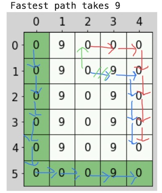

Last iteration and finish, with a joyous "wahoo!"

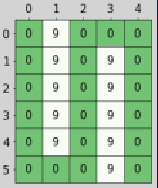

The code has to scan all m x n grid squares on each iteration. The largest number of iterations needed it surely bound by m x n and in practice will be very low. Therefore a finger in the air estimate of worst case complexity is $O(n^2)$ where n is the larger of the two grid dimensions.

## Two easy examples to show the code in action

To illustrate the code, we show one example each of Classic and Relative subclass. I show the result of Dijkstra algorithm as well, and explain the implementation below

### Classic

Parameters:

- grid size is 5 x 7
- grid values are integers between 0 and 9

In this example both algorithims find the same path

```
Starting grid:
```

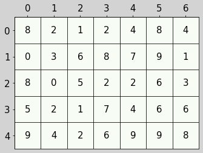

```
----------
iterations of fastest path found by naive algorithm

Fastest path takes 43
```

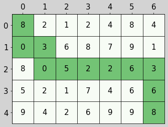

```
Code required 1 iterations

----------
Djikstra algorithm:
fastest path takes 43

Path calculated by djikstra algorithm:
```

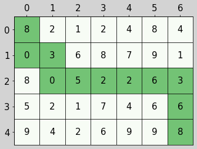

```
CPU times: user 410 ms, sys: 13 ms, total: 423 ms
Wall time: 423 ms
```

```python
%%time
game = Classic(size=(5,7), random_seed=random_seed)
game.set_grid_values(distribution="integers", high=10)
print("\nStarting grid:\n")
game.visualise_grid()
print("\n" + "-"*10)
print("iterations of fastest path found by naive algorithm")
game.solve_game(show_iterations=True)
print("\n" + "-"*10)
print("Djikstra algorithm:")
game.djikstra()
print("\nPath calculated by djikstra algorithm:\n")
game.visualise_grid(game.djikstra_path)
```

```python
game.visited_time[(game.grid.shape[0]-1, game.grid.shape[1]-1)]
```

```
43
```

Parameters:

- grid size is 20 x 20
- grid values are geometrically distributed with parameter $p=0.1$

```
Starting grid:
```

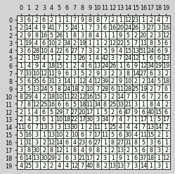

```
----------
iterations of fastest path found by naive algorithm

Fastest path takes 154
```

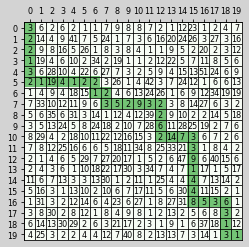

```
Wahoo! Fastest path now takes 152
```

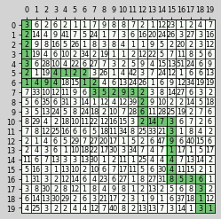

```
Wahoo! Fastest path now takes 151
```

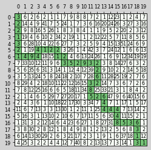

[output not shown]

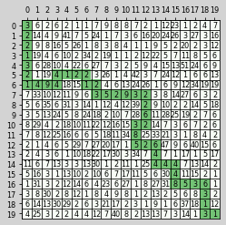

```
CPU times: user 3.16 s, sys: 109 ms, total: 3.27 s
Wall time: 3.27 s
```

```python
%%time
game = Classic(size=(20,20), random_seed=20)
game.set_grid_values(distribution="geometric", p = 0.1)
print("\nStarting grid:\n")
game.visualise_grid()
print("\n" + "-"*10)
print("iterations of fastest path found by naive algorithm")
game.solve_game(show_iterations=True)
print("\n" + "-"*10)
print("Dijkstra algorithm:")
game.djikstra()
print("\nPath calculated by dijkstra algorithm:\n")
game.visualise_grid(game.djikstra_path)
```

## How does Dijkstra algorithm work in my code?

I didn't consult any online resources on how to write the python code for Dijkstra. I just looked at the description of the algorithm on Wikipedia and implemented it as best as I could. With the benefit of several weeks more coding experience I would do a different and better job.

The main `.djikstra()` method calls on the following class methods:

- `.moves()` - the allowable moves from a certain cell. Will be up, down, left, right, as long as they are in the grid. Shared with the naive algorithm.
- `.move_time()` the subclass specific method which calculates how long the agent has to stay in a cell for. Shared with naive algorithm.
- `.create_unvisited_list()` method creates the initial list of unvisited nodes: which is just a list of all nodes in the grid.
- `.djikstra_shortest_path()` method which uses the "previous" cell information held by each cell to iteratively reconstruct the current quickest path from the finishing cell to the starting cell, using the "previous cell" information held in the `self.previous_node` attribute - which is a dictionary with keys that are 2-tuples representing grid location of a node.

The method `.djikstra()` solves the game using Dijkstra's algorithm.

The algorithm initialises a priority queue object (from class PQueue) to store the list of unvisited cells and how long the path is to each of them. The length of path serves as the priority, and at each stage of the Dijkstra algorithm the unvistied cell with the shortest path is taken out, and neighbours of that cell then join the unvisited queue with shortest path information attached. As cells join the queue, the "previous node" information is stored in a dictionary (`.prev_node`) attribute with the location of the cell as key and the previous cell location as value. This value can be updated if a shorter path is established from another cell.

When a cell has been visited, it is popped out of the dictionary object (stored in `PQueue.population` attribute) and put into an attibute called `.visited_time` which is a dictionary with cell locations as keys and time spent travelling to them as values.

The algorithm terminates when the finishing cell becomes visited. It then constructs the shortest path using the information stored in the `.prev_node` attibute.

### How does naive and Dijkstra algorithms' speed compare?

```python
# make a really hard game!
game = Relative(size=(200,200), random_seed=20)
game.set_grid_values(distribution="geometric", p = 0.05)

# print("\nStarting grid:\n")
# game.visualise_grid()
```

```python
%%timeit
# the `.solve_game_timed()` method does the same thing as the .solve_game() method but doesn't print out any visualisations.
# These slow the code down a lot and are not illustrative of the actual algorithm.
game.solve_game_timed()
```

```
576 ms ± 3.8 ms per loop (mean ± std. dev. of 7 runs, 1 loop each)
```

```python
%%timeit
game.djikstra(printout=False)
```

```
943 ms ± 11.4 ms per loop (mean ± std. dev. of 7 runs, 1 loop each)
```

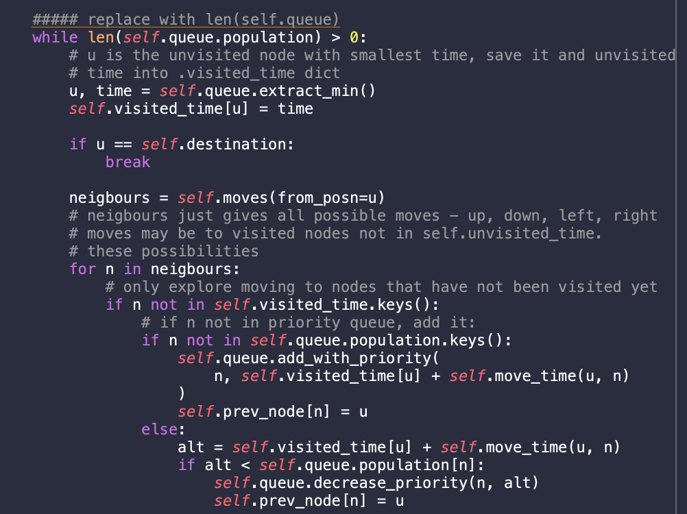

## Effect of changing parameters

### Grid size

#### Classic game

Change the grid size for a classic game with values in uniform distribution between 0 and 9. Change both length and width.

```python
def change_grid_size():
    n = [5, 10, 20, 50, 100, 200]
    m = [5, 10, 20, 50, 100, 200]
    iters = 100
    naive = np.zeros(shape=(len(n),len(m), iters))
    djikstra = np.zeros(shape=(len(n),len(m), iters))
    for i, nn in enumerate(n):
        for j, mm in enumerate(m):
            # no need to do e.g. 5x10 and 10x5 grid because the are symmetric and identical topologically
            if i <= j:
                seed = 0
                for k in list(range(iters)):
                    seed += 1
                    game = Classic(size=(nn,mm), random_seed=seed)
                    game.set_grid_values(distribution="integers", high = 10)
                    game.solve_game_timed()  # we don't want to print any output
                    game.djikstra(printout=False)
                    # store fastest times
                    naive[i,j,k] = game.fastest_path_time[0,0]
                    djikstra[i,j,k] = game.djikstra_time_taken


    naive_avg = naive.mean(axis=2)
    naive_std = naive.std(axis=2)
    djikstra_avg = djikstra.mean(axis=2)
    djikstra_std = djikstra.std(axis=2)

    return naive_avg, djikstra_avg, naive_std, djikstra_std, naive, djikstra

naive_avg, djikstra_avg, naive_std, djikstra_std, naive, djikstra = change_grid_size()
```

Really interesting results. For grid size (m, n), if n < m, and m gets larger, then shortest path gets longer on average as one would expect. However if n > m and m gets larger then the shortest average path decreases and then increases again with m.

I suppose the intuition to this is that if you have a 5 x 200 grid, there are not many options on the first dimension to avoid long waits at cells. IF the grid increases to 10 x 200, then agent is less constrained to move around to find quicker paths. As m gets close to n, the benefit of more freedom is outweight by the fact that the agent has to move down as well as across a large number of square to get to the finish: so average times start going up again.

```python
print("\nChart showing the average shortest path for an (m x 200) grid as m varies:\n")
plt.bar(x = ['5','10','20','50','100','200'], height = djikstra_avg[:,5]);
```

[output not shown]

For this version only, I show output from the naive algorithm and Dijkstra. My naive version gave same minimum path length every time when I manually tested, but when running hundreds of iterations, it clearly doesn't find the shortest path all of the time. From now on, I will investigate parameters with Dijkstra only.

```python
results = [naive_avg, djikstra_avg, naive_std, djikstra_std]
title = ['naive_avg', 'dijkstra_avg', 'naive_std', 'dijkstra_std']
for i, res in enumerate(results):
    print("------------\n{}:\n".format(title[i]))
    display(pd.DataFrame(res, index=[5, 10, 20, 50, 100, 200],
                        columns=[5, 10, 20, 50, 100, 200]).style.format('{:.0f}'))
    print("\n")
```

[output not shown]

#### Relative game

When run for the relative game, the average path length is lower. This is unsurprsing as there are more options for the agent to take a quicker path in the relative game: e.g. in game with cell values as uniform integers between 0 and 9, and cell in the range [2, 8] will have two options for a path that takes one time unit: either the number below or the number above. In the classic game, the only way to find a path of length 1 is to be next to a 1.

The standard deviation is also lower.

The pattern of results are the same as in the classic game, for the same reasons (more freedoom in 10 x 200 grid vs 5 x 200 grid, but by the time you get to 150 x 200, for example, the extra freedom is outweighed by the fact that agent has to move DOWN 150 squares cumulatively before reaching the end).

```python
def change_grid_size():
    n = [5, 10, 20, 50, 100, 200]
    m = [5, 10, 20, 50, 100, 200]
    iters = 100
    djikstra = np.zeros(shape=(len(n),len(m), iters))
    for i, nn in enumerate(n):
        for j, mm in enumerate(m):
            # no need to do e.g. 5x10 and 10x5 grid because the are symmetric and identical topologically
            if i <= j:
                seed = 0
                for k in list(range(iters)):
                    seed += 1
                    game = Relative(size=(nn,mm), random_seed=seed)
                    game.set_grid_values(distribution="integers", high = 10)
                    game.djikstra(printout=False)
                    # store fastest times
                    djikstra[i,j,k] = game.djikstra_time_taken

    djikstra_avg = djikstra.mean(axis=2)
    djikstra_std = djikstra.std(axis=2)

    return djikstra_avg, djikstra_std, djikstra

djikstra_avg, djikstra_std, djikstra = change_grid_size()
```

```python
results = [djikstra_avg, djikstra_std]
title = ['djikstra_avg', 'djikstra_std']
for i, res in enumerate(results):
    print("------------\n{}:\n".format(title[i]))
    display(pd.DataFrame(res, index=[5, 10, 20, 50, 100, 200],
                        columns=[5, 10, 20, 50, 100, 200]).style.format('{:.0f}'))
    print("\n")
```

[output not shown]

```python
plt.hist(djikstra[5,5])
plt.hist(djikstra[0,5])
```

[output not shown]

### Integer range for cell values created with uniform distribution

Next experiment is to draw cell values from a uniform distribution of [0, n), where n is the parameter `high` in rng.integers()

We sample a range of integers and find that for both the Classic and Relative game, the shortest path lenght and standard deviation increase linearly with the integer range.

```python
def change_integer_params(mode=Classic):
    high = [10, 20, 50, 100]
    iters = 100
    djikstra = np.zeros(shape=(len(high), iters))
    for i, h in enumerate(high):
        seed = 0
        for k in list(range(iters)):
            seed += 1
            game = mode(size=(50, 50), random_seed=seed)
            game.set_grid_values(distribution="integers", high = h)
            game.djikstra(printout=False)
            # store fastest times
            djikstra[i,k] = game.djikstra_time_taken

    djikstra_avg = djikstra.mean(axis=1)
    djikstra_std = djikstra.std(axis=1)

    return djikstra_avg, djikstra_std, djikstra

djikstra_avg, djikstra_std, djikstra = change_integer_params(mode=Classic)

print("\nResults for Classic game\n-------\nTable shows n vs mean and std of paths\n")

results = [djikstra_avg, djikstra_std]
title = ['djikstra_avg', 'djikstra_std']
ar = np.concatenate((djikstra_avg.reshape(4,1), djikstra_std.reshape(4,1)), axis=1)
res = pd.DataFrame(ar, index=[10, 20, 50, 100], columns = ["mean", "std"])
display(res.style.format('{:.0f}'))
print("\n")

print("relationship of shortest path to integer range")
res.plot();
```

[output not shown]

```python
djikstra_avg, djikstra_std, djikstra = change_integer_params(mode=Relative)

print("\nResults for Relative game\n-------\nTable shows n vs mean and std of paths\n")

results = [djikstra_avg, djikstra_std]
title = ['djikstra_avg', 'djikstra_std']
ar = np.concatenate((djikstra_avg.reshape(4,1), djikstra_std.reshape(4,1)), axis=1)
res = pd.DataFrame(ar, index=[10, 20, 50, 100], columns = ["mean", "std"])
display(res.style.format('{:.0f}'))
print("\n")

print("relationship of shortest path to integer range")
res.plot();
```

[output not shown]

### Standard deviation for cell values drawn from Normal distibution

We could change the mean of the standard deviation, but this is a boring thing to do. It's a parrallel shift of all cell values, so path length will increas linearly with mean for the Classic game. The standard distribution and path length of the Relative game wont change at all. To be as sure as we can that drawing cell values below zero doesn't happen (the code does handle it if it does - agent will have infinite loops if there are negative squares because it will always choose to go "back in time" by revisiting negative squares), we choose a mean of 600(!) and then reduce the resultant path lengths by a large number (55k). This has no impact on the insights.

This change in parameters is the most interesting so far:

- for the classic game, as standard deviation of cell values increases, the average shortest path linearly decreases. The decrease is because, with a higher standard deviation, there is more likelihood of low cell values to take advantage of when constructing a path.
- For the relative game, as as standard deviation of cell values increases, the average shortest path linearly *increases*. The increase is because, with a higher standard deviation, the expected difference of neighbouring cell values is higher, and so the average path will be longer.

```python
def change_integer_params(mode=Classic):
    scale = [10, 20, 30, 50]
    iters = 100
    djikstra = np.zeros(shape=(len(scale), iters))
    for i, s in enumerate(scale):
        seed = 0
        for k in list(range(iters)):
            seed += 1
            game = mode(size=(50, 50), random_seed=seed)
            game.set_grid_values(distribution="normal", scale = s, loc = 600)
            game.djikstra(printout=False)
            # store fastest times
            djikstra[i,k] = game.djikstra_time_taken

    djikstra_avg = djikstra.mean(axis=1)
    djikstra_std = djikstra.std(axis=1)

    return djikstra_avg, djikstra_std, djikstra

djikstra_avg, djikstra_std, djikstra = change_integer_params(mode=Classic)

print("\nResults for Classic game\n-------\nTable shows std of normal distribution vs mean and std of paths\n")

results = [djikstra_avg, djikstra_std]
title = ['djikstra_avg', 'djikstra_std']
ar = np.concatenate((djikstra_avg.reshape(4,1) - 55000, djikstra_std.reshape(4,1)), axis=1)
res = pd.DataFrame(ar, index=[10, 20, 30, 50], columns = ["mean", "std"])
display(res.style.format('{:.0f}'))
print("\n")

print("relationship of shortest path to standard distribution")
res.plot();
```

[output not shown]

```python
djikstra_avg, djikstra_std, djikstra = change_integer_params(mode=Relative)

print("\nResults for Relative game\n-------\nTable shows std of normal distribution vs mean and std of paths\n")

results = [djikstra_avg, djikstra_std]
title = ['djikstra_avg', 'djikstra_std']
ar = np.concatenate((djikstra_avg.reshape(4,1), djikstra_std.reshape(4,1)), axis=1)
res = pd.DataFrame(ar, index=[10, 20, 30, 50], columns = ["mean", "std"])
display(res.style.format('{:.0f}'))
print("\n")

print("relationship of shortest path to standard distribution")
res.plot();
```

[output not shown]

### Geometric - changing parameter p

The Geometric distribution is like an exponential distribution for integer values. When the p-value is high, there are many many cell values of 1. When p is low there is great variation. Plotting both the mean shortest path and the stadard deviation against different values of p give an expontial like relationship. This is no suprise given the distribution. For high values of p, there is almost always a path available through cells with value 1, so the shortest path of the classic game is m + n, and it is 0 for the relative game.

```python
def change_integer_params(mode=Classic):
    pval = [0.1, 0.2, 0.3, 0.4, 0.5, 0.6, 0.7, 0.8, 0.9]
    iters = 100
    djikstra = np.zeros(shape=(len(pval), iters))
    for i, p in enumerate(pval):
        seed = 0
        for k in list(range(iters)):
            seed += 1
            game = mode(size=(50, 50), random_seed=seed)
            game.set_grid_values(distribution="geometric", p=p)
            game.djikstra(printout=False)
            # store fastest times
            djikstra[i,k] = game.djikstra_time_taken

    djikstra_avg = djikstra.mean(axis=1)
    djikstra_std = djikstra.std(axis=1)

    return djikstra_avg, djikstra_std, djikstra

djikstra_avg, djikstra_std, djikstra = change_integer_params(mode=Classic)

print("\nResults for Classic game\n-------\nTable shows p-value of geometric distribution vs mean and std of paths\n")

results = [djikstra_avg, djikstra_std]
title = ['djikstra_avg', 'djikstra_std']
ar = np.concatenate((djikstra_avg.reshape(9,1), djikstra_std.reshape(9,1)), axis=1)
res = pd.DataFrame(ar, index=[0.1, 0.2, 0.3, 0.4, 0.5, 0.6, 0.7, 0.8, 0.9], columns = ["mean", "std"])
display(res.style.format('{:.0f}'))
print("\n")

print("relationship of shortest path to p-value")
res.plot();
```

[output not shown]

```python
djikstra_avg, djikstra_std, djikstra = change_integer_params(mode=Relative)

print("\nResults for Relative game\n-------\nTable shows p-value of geometric distribution vs mean and std of paths\n")

results = [djikstra_avg, djikstra_std]
title = ['djikstra_avg', 'djikstra_std']
ar = np.concatenate((djikstra_avg.reshape(9,1), djikstra_std.reshape(9,1)), axis=1)
res = pd.DataFrame(ar, index=[0.1, 0.2, 0.3, 0.4, 0.5, 0.6, 0.7, 0.8, 0.9], columns = ["mean", "std"])
display(res.style.format('{:.0f}'))
print("\n")

print("relationship of shortest path to p-value")
res.plot();
```

[output not shown]